# A Short Intro to `norMmix`

```r
library(norMmix)
set.seed(2020)
```

## Ultra quick start

This section is for those who want a quick whiff of what the package can do. For the proper start to this vignette, see next section.

A normal mixture model is a multivariate probability distribution constructed of normal distributions and mixture weights. Its (probability) density and (cumulative) distribution functions (aka PDF and CDF), $f()$ and $F()$ are
$$f({\bf x}) = \sum_{k=1}^{K} \pi_k \phi({\bf x};\mu_k, \Sigma_k),
\text{ and } \\
F({\bf x}) = \sum_{k=1}^{K} \pi_k \Phi({\bf x};\mu_k, \Sigma_k),$$

with $\pi_k \ge 0$, $\sum \pi_k = 1$, and $\phi(\cdot; \mu_k, \Sigma_k)$ and $\Phi(\cdot; \mu_k, \Sigma_k)$ are the density and distribution function of a multivariate normal (aka *Gaussian*) distribution with mean $\mu_k$ and covariance matrix $\Sigma_k$. For details, see e.g., https://en.wikipedia.org/wiki/Multivariate_normal_distribution .

To begin, pick your favorite dataset and how many components you want to fit. For the most general model, let `model="VVV"`. Use `claraInit` as the default method.

run `norMmixMLE`:

```r
faith <- norMmixMLE(faithful, 3, model="VVV", initFUN=claraInit)
```

and inspect the results:

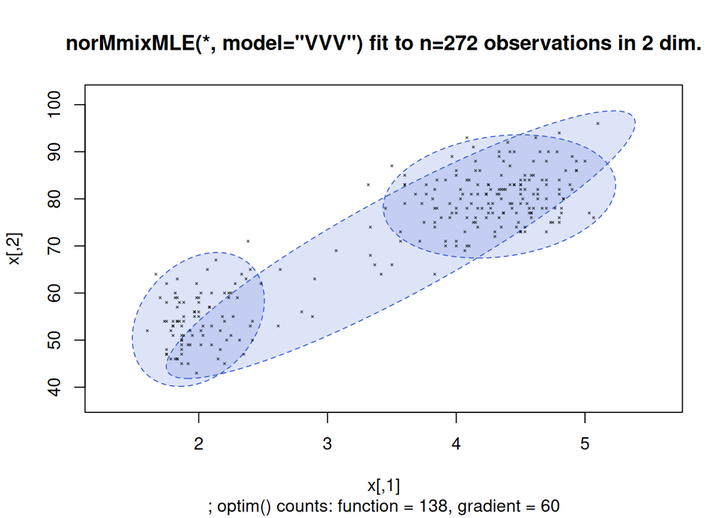

```r
plot(faith)
```

This is all you need to know for just the bare bones functionality of the package. We can also go about the whole thing the other way around, by starting out by defining a normal mixture from scratch.

Use the `norMmix()` function; the constructor function for normal mixtures.

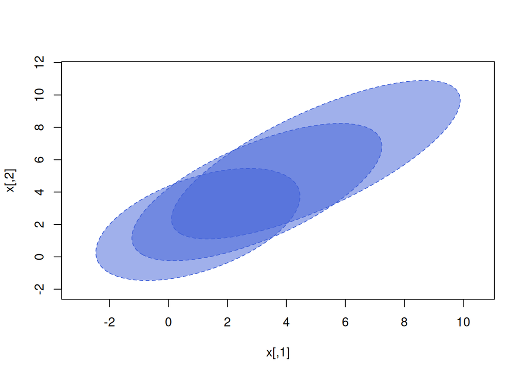

```r
w <- c(0.5, 0.3, 0.2)
mu <- matrix(1:6, 2, 3)
sig <- array(c(2,1,1,2,
               3,2,2,3,
               4,3,3,4), c(2,2,3))
nm <- norMmix(mu, Sigma=sig, weight=w)
plot(nm)
```

higher-dimensional plots are also possible.

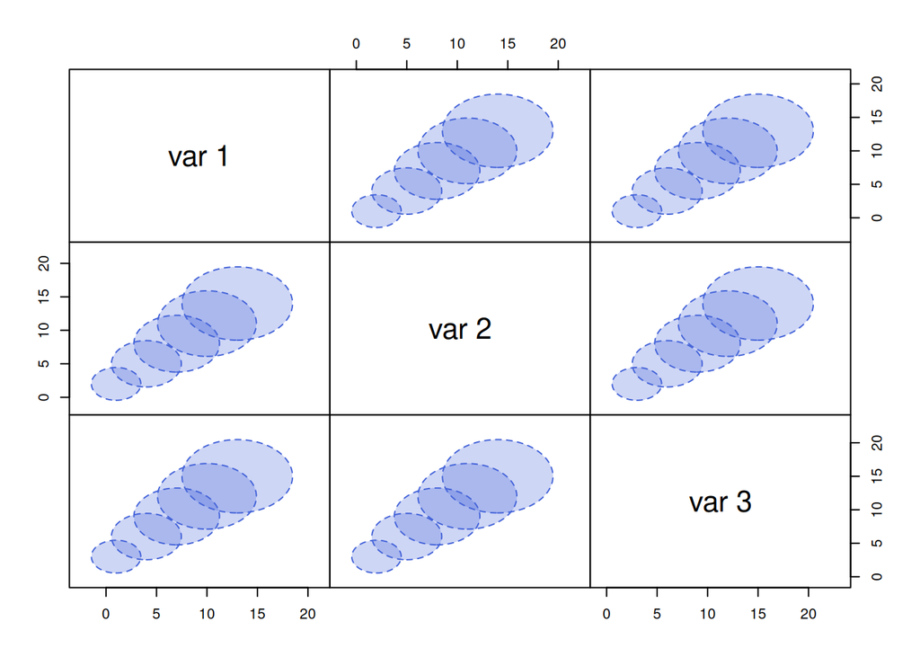

```r
plot(MW32)
```

This model is taken from

Marron, J. S., and Wand, M. P. (1992) “Exact Mean Integrated Squared Error.” doi:10.1214/aos/1176348653.

All the models from this paper are provided in the package as examples.

`rnorMmix()` generates data (random observations) from such distributions:

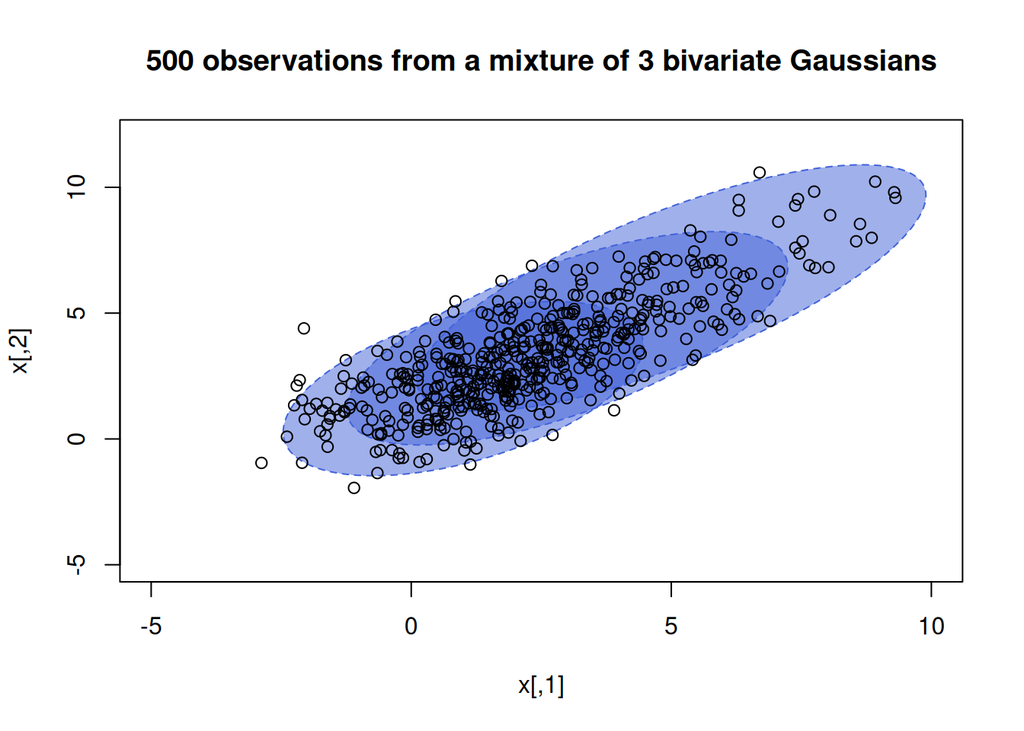

```r
x <- rnorMmix(500, nm)
plot(nm, xlim = c(-5,10), ylim = c(-5, 12),
     main = "500 observations from a mixture of 3 bivariate Gaussians")
points(x)
```

`norMmixMLE()` fits a distribution to data:

```r
ret <- norMmixMLE(x, 3, model="VVV", initFUN=claraInit)
ret # -> print.norMmixMLE(ret)
```

```
#> 'norMmixMLE' normal mixture MLE fit;  fitted 'norMmix' normal mixture:
#> norMmix object:
#> multivariate normal mixture model with the following attributes:
#> name:         model = VVV , components = 3
#>  model:       VVV
#>  dimension:   2
#>  components:  3
#> weight of components 0.613 0.34 0.0466
#> log-likelihood:
#>
#>  nobs     npar    nobs/npar
#>  500      17      29.41176
#>
#>  optim() counts: function = 157, gradient = 58
```

and the fitted object, of class `"norMixMLE"` has a nice `plot()` method:

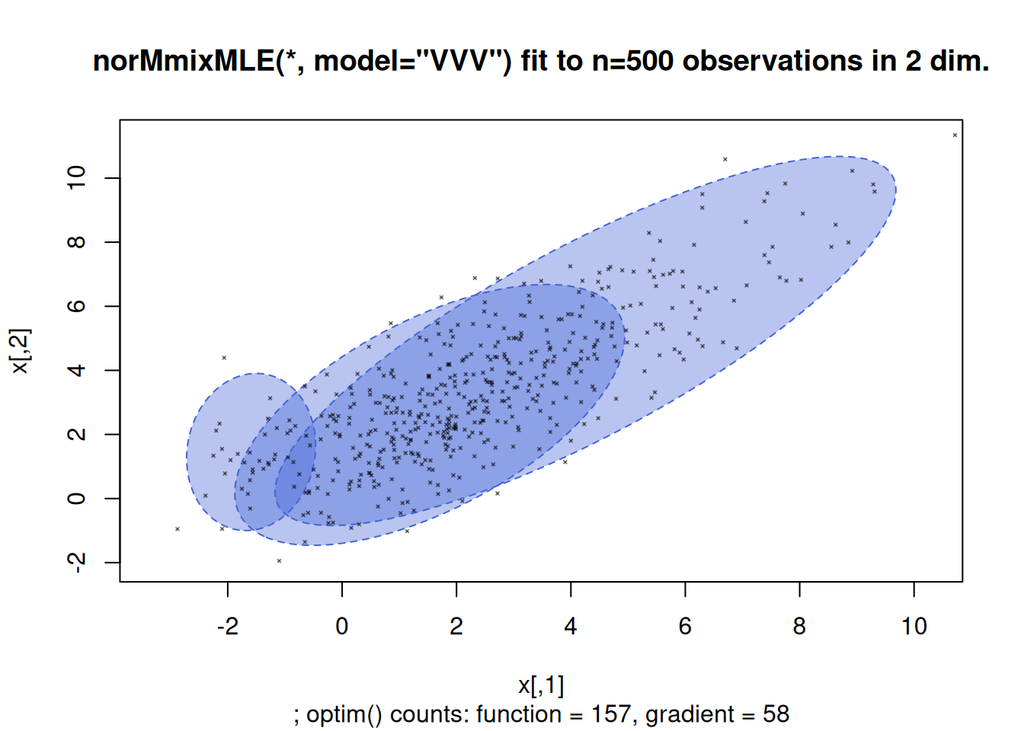

```r
plot(ret)
```

Voilà.

Now again but more thorough:

## Why this package exists:

This package was originally created for the purposes of a bachelor’s thesis from author Nicolas Trutmann. The credit for the idea rests solely with Prof. Martin Mächler.

In brief: The current popular choice for the fitting of normal mixtures is the EM-algorithm; in part because of it’s proven convergence. But, there are pathological cases where convergence slows down and, in most implementations of the EM-algorithm, break off.

This alternative, while not without flaws, is not hampered by this particular shortcoming.

A general reference for Mixture models and in particular a thorough explanation for the EM-algorithm can be found in this reference.

McLachlan, Geoffrey, and David Peel. Finite Mixture Models. PDF. Newy York: Wiley-Interscience, 2004.

This document is organised by the major classes in this package. These are the ‘norMmix’, ‘norMmixMLE’ and (soon) ‘manynorMmix’ classes.

Of these, norMmix is the base class, that codifies a multivariate normal mixture, with weights, means and covariance matrices.

Stacked on top of norMmix is norMmixMLE, which is the output of our main feature, the MLE implementation. It contains first and foremost a norMmix object, namely the result of the MLE. After that, it also has additional information about the specifics of the fitting, like number of parameters and sample size.

## On the base class ‘norMmix’

- how to make a norMmix model

It is easiest to introduce the tool by using the tool, so here is a quick tour:

```r
# suppose we wanted some mixture model, let
mu <- matrix(1:6, 2,3)      # 2x3 matrix -> 3 means of dimension 2
w <- c(0.5, 0.3, 0.2)       # needs to sum to 1
diags <- c(4, 3, 5)         # these will be the entries of the diagonal of the covariance matrices (see below)

nm <- norMmix(mu, Sigma=diags, weight=w)
print(nm)
```

```
#> norMmix object:
#> multivariate normal mixture model with the following attributes:
#> name:         model "VVV", G = 3
#>  model:       VVV
#>  dimension:   2
#>  components:  3
#> weight of components 0.5 0.3 0.2
```

```r
str(nm)
```

```
#> List of 6
#>  $ model : chr "VVV"
#>  $ mu    : int [1:2, 1:3] 1 2 3 4 5 6
#>  $ Sigma : num [1:2, 1:2, 1:3] 4 0 0 4 3 0 0 3 5 0 ...
#>  $ weight: num [1:3] 0.5 0.3 0.2
#>  $ k     : int 3
#>  $ dim   : int 2
#>  - attr(*, "name")= chr "model \"VVV\", G = 3"
#>  - attr(*, "class")= chr "norMmix"
```

A norMmix object is a list of 6: * a char denoting the model * a matrix of means * a vector of weights * an array of covariance matrices * an int: the number of components * an int: the number of dimensions

The means and covariance matrices look like this:

```r
nm$mu
```

```
#>      [,1] [,2] [,3]
#> [1,]    1    3    5
#> [2,]    2    4    6
```

```r
nm$Sigma
```

```
#> , , 1
#>
#>      [,1] [,2]
#> [1,]    4    0
#> [2,]    0    4
#>
#> , , 2
#>
#>      [,1] [,2]
#> [1,]    3    0
#> [2,]    0    3
#>
#> , , 3
#>
#>      [,1] [,2]
#> [1,]    5    0
#> [2,]    0    5
```

Compare that to mu and diags defined at the start of this section.

The norMmix() function serves as initializer for a norMmix object. While you could specify covariance matrices explicitly, norMmix() as a few nifty ways of constructing simpler matrices from smaller givens. This happens according to the dimension of the given value for the Sigma argument:

0. for a single value `l` or NULL, norMmix() assumes all matrices to be diagonal with entries `l` or `1`, respectively.
1. for a vector `v`, `norMmix()` assumes all matrices to be diagonal with the i-th matrix having diagonal entries `v[i]`.
2. for a matrix `m`, `norMmix()` assumes all matrices to be diagonal with diagonal vector `m[,i]` (i.e. it goes by columns).
3. an array is assumed to be the covariance matrices, given explicitly.

### Issues with k or dim = 1

**IMPORTANT ISSUE**

`norMmix` does not handle 1-dimensional mixture models properly. Use `nor1mix` if that is your use case.

## On ‘norMmixMLE’

Direct Maximum Likelihood Estimation (MLE) for multivariate normal mixture models. Performs direct likelihood maximization via `optim`.

norMmixMLE(x, k, model = c(“EII”, “VII”, “EEI”, “VEI”, “EVI”, “VVI”, “EEE”, “VEE”, “EVV”, “VVV”), initFUN = claraInit, ll = c(“nmm”, “mvt”), keep.optr = TRUE, keep.data = keep.optr, method = “BFGS”, maxit = 100, trace = 2, optREPORT = 10, reltol = sqrt(.Machine$double.eps), )

To use `norMmixMLE`, provide a dataset `x` as a numeric `[n x p]` matrix, a number of components to fit, `k`, and a model from the list above.

## On ‘manyMLE’ (as soon as we have reintegrated that)